# Risk Factor Analysis

## Outcome Variable

**Outcome Variable:** sstunted

## Predictor Variables

**Intervention Variable:** birthwt

**Adjustment Set:**

- arm
- sex
- W_mage
- meducyrs
- feducyrs
- vagbrth
- single
- brthmon
- W_parity
- delta_W_mage
- delta_meducyrs
- delta_feducyrs
- delta_vagbrth
- delta_single
- delta_brthmon
- delta_W_parity

## Stratifying Variables

The analysis was stratified on these variable(s):

- agecat
- studyid
- country

## Data Summary

| agecat | studyid | country | birthwt | sstunted | n_cell | n |
| --- | --- | --- | --- | --- | --- | --- |
| Birth | ki0047075b-MAL-ED | BANGLADESH | Normal or high birthweight | 0 | 201 | 257 |
| Birth | ki0047075b-MAL-ED | BANGLADESH | Normal or high birthweight | 1 | 1 | 257 |
| Birth | ki0047075b-MAL-ED | BANGLADESH | Low birth weight | 0 | 47 | 257 |
| Birth | ki0047075b-MAL-ED | BANGLADESH | Low birth weight | 1 | 8 | 257 |
| Birth | ki0047075b-MAL-ED | BRAZIL | Normal or high birthweight | 0 | 179 | 191 |
| Birth | ki0047075b-MAL-ED | BRAZIL | Normal or high birthweight | 1 | 4 | 191 |
| Birth | ki0047075b-MAL-ED | BRAZIL | Low birth weight | 0 | 4 | 191 |
| Birth | ki0047075b-MAL-ED | BRAZIL | Low birth weight | 1 | 4 | 191 |
| Birth | ki0047075b-MAL-ED | INDIA | Normal or high birthweight | 0 | 168 | 206 |
| Birth | ki0047075b-MAL-ED | INDIA | Normal or high birthweight | 1 | 4 | 206 |
| Birth | ki0047075b-MAL-ED | INDIA | Low birth weight | 0 | 31 | 206 |
| Birth | ki0047075b-MAL-ED | INDIA | Low birth weight | 1 | 3 | 206 |
| Birth | ki0047075b-MAL-ED | NEPAL | Normal or high birthweight | 0 | 154 | 173 |
| Birth | ki0047075b-MAL-ED | NEPAL | Normal or high birthweight | 1 | 1 | 173 |
| Birth | ki0047075b-MAL-ED | NEPAL | Low birth weight | 0 | 13 | 173 |
| Birth | ki0047075b-MAL-ED | NEPAL | Low birth weight | 1 | 5 | 173 |
| Birth | ki0047075b-MAL-ED | PERU | Normal or high birthweight | 0 | 267 | 287 |
| Birth | ki0047075b-MAL-ED | PERU | Normal or high birthweight | 1 | 2 | 287 |
| Birth | ki0047075b-MAL-ED | PERU | Low birth weight | 0 | 12 | 287 |
| Birth | ki0047075b-MAL-ED | PERU | Low birth weight | 1 | 6 | 287 |
| Birth | ki0047075b-MAL-ED | SOUTH AFRICA | Normal or high birthweight | 0 | 244 | 262 |
| Birth | ki0047075b-MAL-ED | SOUTH AFRICA | Normal or high birthweight | 1 | 0 | 262 |
| Birth | ki0047075b-MAL-ED | SOUTH AFRICA | Low birth weight | 0 | 16 | 262 |
| Birth | ki0047075b-MAL-ED | SOUTH AFRICA | Low birth weight | 1 | 2 | 262 |
| Birth | ki0047075b-MAL-ED | TANZANIA, UNITED REPUBLIC OF | Normal or high birthweight | 0 | 113 | 123 |
| Birth | ki0047075b-MAL-ED | TANZANIA, UNITED REPUBLIC OF | Normal or high birthweight | 1 | 3 | 123 |
| Birth | ki0047075b-MAL-ED | TANZANIA, UNITED REPUBLIC OF | Low birth weight | 0 | 4 | 123 |
| Birth | ki0047075b-MAL-ED | TANZANIA, UNITED REPUBLIC OF | Low birth weight | 1 | 3 | 123 |
| Birth | ki1000108-CMC-V-BCS-2002 | INDIA | Normal or high birthweight | 0 | 77 | 90 |
| Birth | ki1000108-CMC-V-BCS-2002 | INDIA | Normal or high birthweight | 1 | 3 | 90 |

[output cut: 286 more lines]

The following strata were considered:

- agecat: 24 months, studyid: ki0047075b-MAL-ED, country: BANGLADESH
- agecat: 24 months, studyid: ki0047075b-MAL-ED, country: BRAZIL
- agecat: 24 months, studyid: ki0047075b-MAL-ED, country: INDIA
- agecat: 24 months, studyid: ki0047075b-MAL-ED, country: NEPAL
- agecat: 24 months, studyid: ki0047075b-MAL-ED, country: PERU
- agecat: 24 months, studyid: ki0047075b-MAL-ED, country: SOUTH AFRICA
- agecat: 24 months, studyid: ki0047075b-MAL-ED, country: TANZANIA, UNITED REPUBLIC OF
- agecat: 24 months, studyid: ki1000108-CMC-V-BCS-2002, country: INDIA
- agecat: 24 months, studyid: ki1000108-IRC, country: INDIA
- agecat: 24 months, studyid: ki1017093-NIH-Birth, country: BANGLADESH
- agecat: 24 months, studyid: ki1017093b-PROVIDE, country: BANGLADESH
- agecat: 24 months, studyid: ki1017093c-NIH-Crypto, country: BANGLADESH
- agecat: 24 months, studyid: ki1066203-TanzaniaChild2, country: TANZANIA, UNITED REPUBLIC OF
- agecat: 24 months, studyid: ki1101329-Keneba, country: GAMBIA
- agecat: 24 months, studyid: ki1114097-CMIN, country: BANGLADESH
- agecat: 24 months, studyid: ki1114097-CMIN, country: PERU
- agecat: 24 months, studyid: ki1114097-CONTENT, country: PERU
- agecat: 24 months, studyid: ki1119695-PROBIT, country: BELARUS
- agecat: 24 months, studyid: ki1126311-ZVITAMBO, country: ZIMBABWE
- agecat: 24 months, studyid: ki1135781-COHORTS, country: GUATEMALA
- agecat: 24 months, studyid: ki1135781-COHORTS, country: INDIA
- agecat: 24 months, studyid: ki1135781-COHORTS, country: PHILIPPINES
- agecat: 24 months, studyid: kiGH5241-JiVitA-3, country: BANGLADESH
- agecat: 24 months, studyid: kiGH5241-JiVitA-4, country: BANGLADESH
- agecat: 6 months, studyid: ki0047075b-MAL-ED, country: BANGLADESH
- agecat: 6 months, studyid: ki0047075b-MAL-ED, country: BRAZIL
- agecat: 6 months, studyid: ki0047075b-MAL-ED, country: INDIA
- agecat: 6 months, studyid: ki0047075b-MAL-ED, country: NEPAL
- agecat: 6 months, studyid: ki0047075b-MAL-ED, country: PERU
- agecat: 6 months, studyid: ki0047075b-MAL-ED, country: SOUTH AFRICA
- agecat: 6 months, studyid: ki0047075b-MAL-ED, country: TANZANIA, UNITED REPUBLIC OF
- agecat: 6 months, studyid: ki1000108-CMC-V-BCS-2002, country: INDIA
- agecat: 6 months, studyid: ki1000108-IRC, country: INDIA
- agecat: 6 months, studyid: ki1000109-EE, country: PAKISTAN
- agecat: 6 months, studyid: ki1000109-ResPak, country: PAKISTAN
- agecat: 6 months, studyid: ki1000304b-SAS-CompFeed, country: INDIA
- agecat: 6 months, studyid: ki1017093-NIH-Birth, country: BANGLADESH
- agecat: 6 months, studyid: ki1017093b-PROVIDE, country: BANGLADESH
- agecat: 6 months, studyid: ki1017093c-NIH-Crypto, country: BANGLADESH
- agecat: 6 months, studyid: ki1066203-TanzaniaChild2, country: TANZANIA, UNITED REPUBLIC OF
- agecat: 6 months, studyid: ki1101329-Keneba, country: GAMBIA
- agecat: 6 months, studyid: ki1114097-CMIN, country: BANGLADESH
- agecat: 6 months, studyid: ki1114097-CMIN, country: BRAZIL
- agecat: 6 months, studyid: ki1114097-CMIN, country: GUINEA-BISSAU
- agecat: 6 months, studyid: ki1114097-CMIN, country: PERU
- agecat: 6 months, studyid: ki1114097-CONTENT, country: PERU
- agecat: 6 months, studyid: ki1119695-PROBIT, country: BELARUS
- agecat: 6 months, studyid: ki1126311-ZVITAMBO, country: ZIMBABWE
- agecat: 6 months, studyid: ki1135781-COHORTS, country: GUATEMALA
- agecat: 6 months, studyid: ki1135781-COHORTS, country: INDIA
- agecat: 6 months, studyid: ki1135781-COHORTS, country: PHILIPPINES
- agecat: 6 months, studyid: kiGH5241-JiVitA-3, country: BANGLADESH
- agecat: 6 months, studyid: kiGH5241-JiVitA-4, country: BANGLADESH
- agecat: Birth, studyid: ki0047075b-MAL-ED, country: BANGLADESH
- agecat: Birth, studyid: ki0047075b-MAL-ED, country: BRAZIL
- agecat: Birth, studyid: ki0047075b-MAL-ED, country: INDIA
- agecat: Birth, studyid: ki0047075b-MAL-ED, country: NEPAL
- agecat: Birth, studyid: ki0047075b-MAL-ED, country: PERU
- agecat: Birth, studyid: ki0047075b-MAL-ED, country: SOUTH AFRICA
- agecat: Birth, studyid: ki0047075b-MAL-ED, country: TANZANIA, UNITED REPUBLIC OF
- agecat: Birth, studyid: ki1000108-CMC-V-BCS-2002, country: INDIA
- agecat: Birth, studyid: ki1000108-IRC, country: INDIA
- agecat: Birth, studyid: ki1000109-EE, country: PAKISTAN
- agecat: Birth, studyid: ki1000109-ResPak, country: PAKISTAN
- agecat: Birth, studyid: ki1000304b-SAS-CompFeed, country: INDIA
- agecat: Birth, studyid: ki1017093-NIH-Birth, country: BANGLADESH
- agecat: Birth, studyid: ki1017093c-NIH-Crypto, country: BANGLADESH
- agecat: Birth, studyid: ki1101329-Keneba, country: GAMBIA
- agecat: Birth, studyid: ki1114097-CMIN, country: BANGLADESH
- agecat: Birth, studyid: ki1114097-CMIN, country: BRAZIL
- agecat: Birth, studyid: ki1114097-CMIN, country: PERU
- agecat: Birth, studyid: ki1114097-CONTENT, country: PERU
- agecat: Birth, studyid: ki1119695-PROBIT, country: BELARUS
- agecat: Birth, studyid: ki1126311-ZVITAMBO, country: ZIMBABWE
- agecat: Birth, studyid: ki1135781-COHORTS, country: GUATEMALA
- agecat: Birth, studyid: ki1135781-COHORTS, country: INDIA
- agecat: Birth, studyid: ki1135781-COHORTS, country: PHILIPPINES
- agecat: Birth, studyid: kiGH5241-JiVitA-3, country: BANGLADESH
- agecat: Birth, studyid: kiGH5241-JiVitA-4, country: BANGLADESH

### Dropped Strata

Some strata were dropped due to rare outcomes:

- agecat: Birth, studyid: ki0047075b-MAL-ED, country: BANGLADESH
- agecat: Birth, studyid: ki0047075b-MAL-ED, country: BRAZIL
- agecat: Birth, studyid: ki0047075b-MAL-ED, country: INDIA
- agecat: Birth, studyid: ki0047075b-MAL-ED, country: NEPAL
- agecat: Birth, studyid: ki0047075b-MAL-ED, country: PERU
- agecat: Birth, studyid: ki0047075b-MAL-ED, country: SOUTH AFRICA
- agecat: Birth, studyid: ki0047075b-MAL-ED, country: TANZANIA, UNITED REPUBLIC OF
- agecat: Birth, studyid: ki1000108-CMC-V-BCS-2002, country: INDIA
- agecat: Birth, studyid: ki1000109-EE, country: PAKISTAN
- agecat: Birth, studyid: ki1000109-ResPak, country: PAKISTAN
- agecat: Birth, studyid: ki1000304b-SAS-CompFeed, country: INDIA
- agecat: Birth, studyid: ki1017093-NIH-Birth, country: BANGLADESH
- agecat: Birth, studyid: ki1017093c-NIH-Crypto, country: BANGLADESH
- agecat: Birth, studyid: ki1114097-CMIN, country: BANGLADESH
- agecat: Birth, studyid: ki1114097-CMIN, country: BRAZIL
- agecat: Birth, studyid: ki1114097-CMIN, country: PERU
- agecat: Birth, studyid: ki1114097-CONTENT, country: PERU
- agecat: Birth, studyid: ki1119695-PROBIT, country: BELARUS
- agecat: Birth, studyid: ki1135781-COHORTS, country: GUATEMALA
- agecat: Birth, studyid: kiGH5241-JiVitA-4, country: BANGLADESH
- agecat: 6 months, studyid: ki0047075b-MAL-ED, country: BANGLADESH
- agecat: 6 months, studyid: ki0047075b-MAL-ED, country: BRAZIL
- agecat: 6 months, studyid: ki0047075b-MAL-ED, country: INDIA
- agecat: 6 months, studyid: ki0047075b-MAL-ED, country: NEPAL
- agecat: 6 months, studyid: ki0047075b-MAL-ED, country: SOUTH AFRICA
- agecat: 6 months, studyid: ki0047075b-MAL-ED, country: TANZANIA, UNITED REPUBLIC OF
- agecat: 6 months, studyid: ki1000109-ResPak, country: PAKISTAN
- agecat: 6 months, studyid: ki1017093-NIH-Birth, country: BANGLADESH
- agecat: 6 months, studyid: ki1017093b-PROVIDE, country: BANGLADESH
- agecat: 6 months, studyid: ki1066203-TanzaniaChild2, country: TANZANIA, UNITED REPUBLIC OF
- agecat: 6 months, studyid: ki1114097-CMIN, country: BANGLADESH
- agecat: 6 months, studyid: ki1114097-CMIN, country: BRAZIL
- agecat: 6 months, studyid: ki1114097-CMIN, country: GUINEA-BISSAU
- agecat: 6 months, studyid: ki1114097-CMIN, country: PERU
- agecat: 6 months, studyid: ki1114097-CONTENT, country: PERU
- agecat: 6 months, studyid: ki1119695-PROBIT, country: BELARUS
- agecat: 24 months, studyid: ki0047075b-MAL-ED, country: BRAZIL
- agecat: 24 months, studyid: ki0047075b-MAL-ED, country: NEPAL
- agecat: 24 months, studyid: ki0047075b-MAL-ED, country: PERU
- agecat: 24 months, studyid: ki0047075b-MAL-ED, country: SOUTH AFRICA
- agecat: 24 months, studyid: ki0047075b-MAL-ED, country: TANZANIA, UNITED REPUBLIC OF
- agecat: 24 months, studyid: ki1066203-TanzaniaChild2, country: TANZANIA, UNITED REPUBLIC OF
- agecat: 24 months, studyid: ki1114097-CMIN, country: BANGLADESH
- agecat: 24 months, studyid: ki1114097-CMIN, country: PERU
- agecat: 24 months, studyid: ki1114097-CONTENT, country: PERU
- agecat: 24 months, studyid: ki1119695-PROBIT, country: BELARUS

## Methods Detail

We’re interested in the causal parameters $E[Y_a]$ for all values of $a \in \mathcal{A}$. These parameters represent the mean outcome if, possibly contrary to fact, we intervened to set all units to have $A=a$. Under the randomization and positivity assumptions, these are identified by the statistical parameters $\psi_a=E_W[E_{Y|A,W}(Y|A=a,W)]$. In addition, we’re interested in the mean of $Y$, $E[Y]$ under no intervention (the observed mean). We will estimate these parameters by using SuperLearner to fit the relevant likelihood factors – $E_{Y|A,W}(Y|A=a,W)$ and $p(A=a|W)$, and then updating our likelihood fit using a joint TMLE.

For unadjusted analyses ($W=\{\}$), initial likelihoods were estimated using Lrnr_glm to estimate the simple $E(Y|A)$ and Lrnr_mean to estimate $p(A)$. For adjusted analyses, a small library containing Lrnr_glmnet, Lrnr_xgboost, and Lrnr_mean was used.

Having estimated these parameters, we will then use the delta method to estimate relative risks and attributable risks relative to a prespecified baseline level of $A$.

# Results Detail

## Results Plots

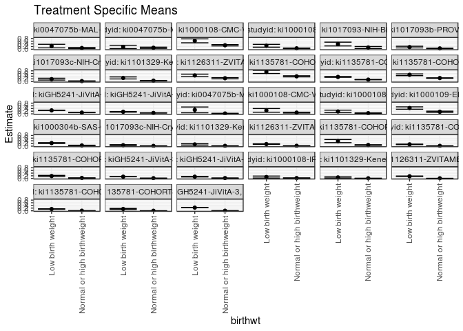

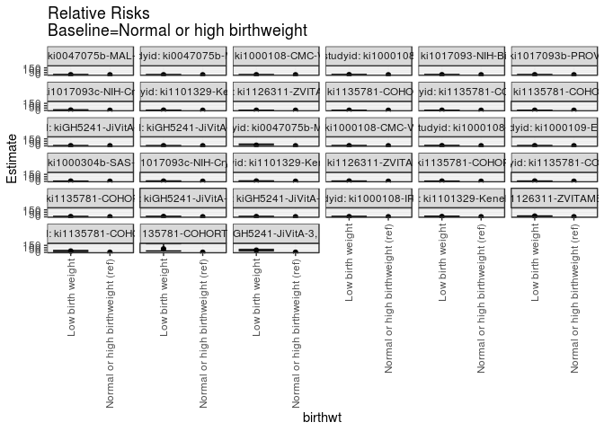

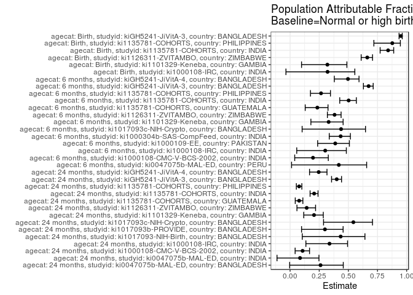

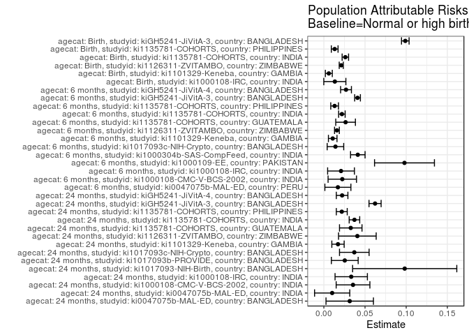

## Results Table

### Parameter: TSM

| agecat | studyid | country | intervention_level | baseline_level | estimate | ci_lower | ci_upper |
| --- | --- | --- | --- | --- | --- | --- | --- |
| Birth | ki1000108-IRC | INDIA | Normal or high birthweight | NA | 0.0281250 | 0.0099871 | 0.0462629 |
| Birth | ki1000108-IRC | INDIA | Low birth weight | NA | 0.1060606 | 0.0316782 | 0.1804431 |
| Birth | ki1101329-Keneba | GAMBIA | Normal or high birthweight | NA | 0.0127959 | 0.0069095 | 0.0186822 |
| Birth | ki1101329-Keneba | GAMBIA | Low birth weight | NA | 0.0781538 | 0.0340571 | 0.1222504 |
| Birth | ki1126311-ZVITAMBO | ZIMBABWE | Normal or high birthweight | NA | 0.0107727 | 0.0089203 | 0.0126251 |
| Birth | ki1126311-ZVITAMBO | ZIMBABWE | Low birth weight | NA | 0.1658318 | 0.1488644 | 0.1827991 |
| Birth | ki1135781-COHORTS | INDIA | Normal or high birthweight | NA | 0.0049335 | 0.0030404 | 0.0068267 |
| Birth | ki1135781-COHORTS | INDIA | Low birth weight | NA | 0.1310201 | 0.1129209 | 0.1491194 |
| Birth | ki1135781-COHORTS | PHILIPPINES | Normal or high birthweight | NA | 0.0018457 | 0.0002291 | 0.0034623 |
| Birth | ki1135781-COHORTS | PHILIPPINES | Low birth weight | NA | 0.1355932 | 0.0965193 | 0.1746672 |
| Birth | kiGH5241-JiVitA-3 | BANGLADESH | Normal or high birthweight | NA | 0.0051525 | 0.0037238 | 0.0065813 |
| Birth | kiGH5241-JiVitA-3 | BANGLADESH | Low birth weight | NA | 0.2362862 | 0.2264179 | 0.2461545 |
| 6 months | ki0047075b-MAL-ED | PERU | Normal or high birthweight | NA | 0.0237154 | 0.0049310 | 0.0424998 |
| 6 months | ki0047075b-MAL-ED | PERU | Low birth weight | NA | 0.2941176 | 0.0771195 | 0.5111158 |
| 6 months | ki1000108-CMC-V-BCS-2002 | INDIA | Normal or high birthweight | NA | 0.0914500 | 0.0600901 | 0.1228100 |
| 6 months | ki1000108-CMC-V-BCS-2002 | INDIA | Low birth weight | NA | 0.2582148 | 0.1199219 | 0.3965077 |
| 6 months | ki1000108-IRC | INDIA | Normal or high birthweight | NA | 0.0482962 | 0.0256918 | 0.0709007 |
| 6 months | ki1000108-IRC | INDIA | Low birth weight | NA | 0.1793672 | 0.0846118 | 0.2741225 |
| 6 months | ki1000109-EE | PAKISTAN | Normal or high birthweight | NA | 0.1547646 | 0.1087714 | 0.2007579 |
| 6 months | ki1000109-EE | PAKISTAN | Low birth weight | NA | 0.4342717 | 0.3468798 | 0.5216635 |
| 6 months | ki1000304b-SAS-CompFeed | INDIA | Normal or high birthweight | NA | 0.0538012 | 0.0376379 | 0.0699645 |
| 6 months | ki1000304b-SAS-CompFeed | INDIA | Low birth weight | NA | 0.2302899 | 0.1959868 | 0.2645930 |
| 6 months | ki1017093c-NIH-Crypto | BANGLADESH | Normal or high birthweight | NA | 0.0180980 | 0.0068187 | 0.0293773 |
| 6 months | ki1017093c-NIH-Crypto | BANGLADESH | Low birth weight | NA | 0.0714223 | 0.0309561 | 0.1118886 |
| 6 months | ki1101329-Keneba | GAMBIA | Normal or high birthweight | NA | 0.0217231 | 0.0145021 | 0.0289441 |
| 6 months | ki1101329-Keneba | GAMBIA | Low birth weight | NA | 0.1313859 | 0.0795650 | 0.1832068 |
| 6 months | ki1126311-ZVITAMBO | ZIMBABWE | Normal or high birthweight | NA | 0.0257416 | 0.0220845 | 0.0293987 |
| 6 months | ki1126311-ZVITAMBO | ZIMBABWE | Low birth weight | NA | 0.1559878 | 0.1341876 | 0.1777880 |
| 6 months | ki1135781-COHORTS | GUATEMALA | Normal or high birthweight | NA | 0.0864661 | 0.0656677 | 0.1072645 |
| 6 months | ki1135781-COHORTS | GUATEMALA | Low birth weight | NA | 0.3789822 | 0.2620834 | 0.4958810 |
| 6 months | ki1135781-COHORTS | INDIA | Normal or high birthweight | NA | 0.0217042 | 0.0176624 | 0.0257460 |
| 6 months | ki1135781-COHORTS | INDIA | Low birth weight | NA | 0.1356761 | 0.1167987 | 0.1545534 |
| 6 months | ki1135781-COHORTS | PHILIPPINES | Normal or high birthweight | NA | 0.0360888 | 0.0286422 | 0.0435354 |
| 6 months | ki1135781-COHORTS | PHILIPPINES | Low birth weight | NA | 0.1819526 | 0.1337610 | 0.2301442 |
| 6 months | kiGH5241-JiVitA-3 | BANGLADESH | Normal or high birthweight | NA | 0.0198026 | 0.0168792 | 0.0227261 |
| 6 months | kiGH5241-JiVitA-3 | BANGLADESH | Low birth weight | NA | 0.1339733 | 0.1250813 | 0.1428654 |
| 6 months | kiGH5241-JiVitA-4 | BANGLADESH | Normal or high birthweight | NA | 0.0272891 | 0.0197077 | 0.0348704 |
| 6 months | kiGH5241-JiVitA-4 | BANGLADESH | Low birth weight | NA | 0.1352019 | 0.1108533 | 0.1595504 |
| 24 months | ki0047075b-MAL-ED | BANGLADESH | Normal or high birthweight | NA | 0.0887916 | 0.0447787 | 0.1328045 |
| 24 months | ki0047075b-MAL-ED | BANGLADESH | Low birth weight | NA | 0.2356774 | 0.1028868 | 0.3684680 |
| 24 months | ki0047075b-MAL-ED | INDIA | Normal or high birthweight | NA | 0.1081081 | 0.0632608 | 0.1529555 |
| 24 months | ki0047075b-MAL-ED | INDIA | Low birth weight | NA | 0.1714286 | 0.0462846 | 0.2965725 |
| 24 months | ki1000108-CMC-V-BCS-2002 | INDIA | Normal or high birthweight | NA | 0.2952317 | 0.2458482 | 0.3446153 |
| 24 months | ki1000108-CMC-V-BCS-2002 | INDIA | Low birth weight | NA | 0.6275505 | 0.4803975 | 0.7747035 |
| 24 months | ki1000108-IRC | INDIA | Normal or high birthweight | NA | 0.0650552 | 0.0387501 | 0.0913602 |
| 24 months | ki1000108-IRC | INDIA | Low birth weight | NA | 0.2583242 | 0.1524296 | 0.3642188 |
| 24 months | ki1017093-NIH-Birth | BANGLADESH | Normal or high birthweight | NA | 0.1280857 | 0.0537144 | 0.2024570 |
| 24 months | ki1017093-NIH-Birth | BANGLADESH | Low birth weight | NA | 0.3870863 | 0.2456192 | 0.5285534 |
| 24 months | ki1017093b-PROVIDE | BANGLADESH | Normal or high birthweight | NA | 0.0595334 | 0.0373279 | 0.0817390 |
| 24 months | ki1017093b-PROVIDE | BANGLADESH | Low birth weight | NA | 0.1592188 | 0.0964394 | 0.2219983 |
| 24 months | ki1017093c-NIH-Crypto | BANGLADESH | Normal or high birthweight | NA | 0.0311209 | 0.0138571 | 0.0483846 |
| 24 months | ki1017093c-NIH-Crypto | BANGLADESH | Low birth weight | NA | 0.1765658 | 0.1082728 | 0.2448589 |
| 24 months | ki1101329-Keneba | GAMBIA | Normal or high birthweight | NA | 0.0664065 | 0.0528255 | 0.0799876 |
| 24 months | ki1101329-Keneba | GAMBIA | Low birth weight | NA | 0.2685741 | 0.1923037 | 0.3448446 |
| 24 months | ki1126311-ZVITAMBO | ZIMBABWE | Normal or high birthweight | NA | 0.2450264 | 0.2004879 | 0.2895650 |
| 24 months | ki1126311-ZVITAMBO | ZIMBABWE | Low birth weight | NA | 0.4547705 | 0.3565281 | 0.5530129 |
| 24 months | ki1135781-COHORTS | GUATEMALA | Normal or high birthweight | NA | 0.3884798 | 0.3491694 | 0.4277901 |
| 24 months | ki1135781-COHORTS | GUATEMALA | Low birth weight | NA | 0.7204800 | 0.6017878 | 0.8391721 |
| 24 months | ki1135781-COHORTS | INDIA | Normal or high birthweight | NA | 0.1428547 | 0.1319565 | 0.1537528 |
| 24 months | ki1135781-COHORTS | INDIA | Low birth weight | NA | 0.3455566 | 0.3148714 | 0.3762417 |
| 24 months | ki1135781-COHORTS | PHILIPPINES | Normal or high birthweight | NA | 0.2587986 | 0.2404619 | 0.2771354 |
| 24 months | ki1135781-COHORTS | PHILIPPINES | Low birth weight | NA | 0.5048174 | 0.4378021 | 0.5718327 |
| 24 months | kiGH5241-JiVitA-3 | BANGLADESH | Normal or high birthweight | NA | 0.0932211 | 0.0845160 | 0.1019263 |
| 24 months | kiGH5241-JiVitA-3 | BANGLADESH | Low birth weight | NA | 0.2604569 | 0.2435634 | 0.2773504 |
| 24 months | kiGH5241-JiVitA-4 | BANGLADESH | Normal or high birthweight | NA | 0.0681217 | 0.0575501 | 0.0786934 |
| 24 months | kiGH5241-JiVitA-4 | BANGLADESH | Low birth weight | NA | 0.1526380 | 0.1281285 | 0.1771475 |

### Parameter: E(Y)

| agecat | studyid | country | intervention_level | baseline_level | estimate | ci_lower | ci_upper |
| --- | --- | --- | --- | --- | --- | --- | --- |
| Birth | ki1000108-IRC | INDIA | NA | NA | 0.0414508 | 0.0215399 | 0.0613617 |
| Birth | ki1101329-Keneba | GAMBIA | NA | NA | 0.0188189 | 0.0120322 | 0.0256057 |
| Birth | ki1126311-ZVITAMBO | ZIMBABWE | NA | NA | 0.0318872 | 0.0289588 | 0.0348156 |
| Birth | ki1135781-COHORTS | INDIA | NA | NA | 0.0310334 | 0.0268616 | 0.0352053 |
| Birth | ki1135781-COHORTS | PHILIPPINES | NA | NA | 0.0149800 | 0.0106354 | 0.0193246 |
| Birth | kiGH5241-JiVitA-3 | BANGLADESH | NA | NA | 0.1040689 | 0.0993991 | 0.1087387 |
| 6 months | ki0047075b-MAL-ED | PERU | NA | NA | 0.0407407 | 0.0171167 | 0.0643648 |
| 6 months | ki1000108-CMC-V-BCS-2002 | INDIA | NA | NA | 0.1138211 | 0.0813725 | 0.1462698 |
| 6 months | ki1000108-IRC | INDIA | NA | NA | 0.0691358 | 0.0443985 | 0.0938731 |
| 6 months | ki1000109-EE | PAKISTAN | NA | NA | 0.2526882 | 0.2084696 | 0.2969067 |
| 6 months | ki1000304b-SAS-CompFeed | INDIA | NA | NA | 0.0950226 | 0.0765320 | 0.1135132 |
| 6 months | ki1017093c-NIH-Crypto | BANGLADESH | NA | NA | 0.0321678 | 0.0192256 | 0.0451101 |
| 6 months | ki1101329-Keneba | GAMBIA | NA | NA | 0.0324638 | 0.0240979 | 0.0408297 |
| 6 months | ki1126311-ZVITAMBO | ZIMBABWE | NA | NA | 0.0416213 | 0.0373152 | 0.0459273 |
| 6 months | ki1135781-COHORTS | GUATEMALA | NA | NA | 0.1128405 | 0.0904926 | 0.1351883 |
| 6 months | ki1135781-COHORTS | INDIA | NA | NA | 0.0436033 | 0.0385446 | 0.0486620 |
| 6 months | ki1135781-COHORTS | PHILIPPINES | NA | NA | 0.0491373 | 0.0409307 | 0.0573439 |
| 6 months | kiGH5241-JiVitA-3 | BANGLADESH | NA | NA | 0.0606930 | 0.0568470 | 0.0645389 |
| 6 months | kiGH5241-JiVitA-4 | BANGLADESH | NA | NA | 0.0541945 | 0.0457550 | 0.0626340 |
| 24 months | ki0047075b-MAL-ED | BANGLADESH | NA | NA | 0.1201923 | 0.0758932 | 0.1644914 |
| 24 months | ki0047075b-MAL-ED | INDIA | NA | NA | 0.1181818 | 0.0754264 | 0.1609372 |
| 24 months | ki1000108-CMC-V-BCS-2002 | INDIA | NA | NA | 0.3306452 | 0.2827744 | 0.3785159 |
| 24 months | ki1000108-IRC | INDIA | NA | NA | 0.0982801 | 0.0693231 | 0.1272371 |
| 24 months | ki1017093-NIH-Birth | BANGLADESH | NA | NA | 0.2262774 | 0.1559553 | 0.2965995 |
| 24 months | ki1017093b-PROVIDE | BANGLADESH | NA | NA | 0.0849220 | 0.0621566 | 0.1076874 |
| 24 months | ki1017093c-NIH-Crypto | BANGLADESH | NA | NA | 0.0680934 | 0.0462948 | 0.0898920 |
| 24 months | ki1101329-Keneba | GAMBIA | NA | NA | 0.0835655 | 0.0692473 | 0.0978836 |
| 24 months | ki1126311-ZVITAMBO | ZIMBABWE | NA | NA | 0.2857143 | 0.2441594 | 0.3272692 |
| 24 months | ki1135781-COHORTS | GUATEMALA | NA | NA | 0.4211332 | 0.3832346 | 0.4590318 |
| 24 months | ki1135781-COHORTS | INDIA | NA | NA | 0.1800041 | 0.1692028 | 0.1908054 |
| 24 months | ki1135781-COHORTS | PHILIPPINES | NA | NA | 0.2805486 | 0.2625932 | 0.2985040 |
| 24 months | kiGH5241-JiVitA-3 | BANGLADESH | NA | NA | 0.1554054 | 0.1466191 | 0.1641917 |
| 24 months | kiGH5241-JiVitA-4 | BANGLADESH | NA | NA | 0.0902743 | 0.0800792 | 0.1004695 |

### Parameter: RR

| agecat | studyid | country | intervention_level | baseline_level | estimate | ci_lower | ci_upper |
| --- | --- | --- | --- | --- | --- | --- | --- |
| Birth | ki1000108-IRC | INDIA | Normal or high birthweight | Normal or high birthweight | 1.000000 | 1.0000000 | 1.000000 |
| Birth | ki1000108-IRC | INDIA | Low birth weight | Normal or high birthweight | 3.771044 | 1.4543975 | 9.777775 |
| Birth | ki1101329-Keneba | GAMBIA | Normal or high birthweight | Normal or high birthweight | 1.000000 | 1.0000000 | 1.000000 |
| Birth | ki1101329-Keneba | GAMBIA | Low birth weight | Normal or high birthweight | 6.107742 | 2.9481911 | 12.653355 |
| Birth | ki1126311-ZVITAMBO | ZIMBABWE | Normal or high birthweight | Normal or high birthweight | 1.000000 | 1.0000000 | 1.000000 |
| Birth | ki1126311-ZVITAMBO | ZIMBABWE | Low birth weight | Normal or high birthweight | 15.393729 | 12.6015412 | 18.804596 |
| Birth | ki1135781-COHORTS | INDIA | Normal or high birthweight | Normal or high birthweight | 1.000000 | 1.0000000 | 1.000000 |
| Birth | ki1135781-COHORTS | INDIA | Low birth weight | Normal or high birthweight | 26.557164 | 17.6634064 | 39.929045 |
| Birth | ki1135781-COHORTS | PHILIPPINES | Normal or high birthweight | Normal or high birthweight | 1.000000 | 1.0000000 | 1.000000 |
| Birth | ki1135781-COHORTS | PHILIPPINES | Low birth weight | Normal or high birthweight | 73.464407 | 29.2170860 | 184.721332 |
| Birth | kiGH5241-JiVitA-3 | BANGLADESH | Normal or high birthweight | Normal or high birthweight | 1.000000 | 1.0000000 | 1.000000 |
| Birth | kiGH5241-JiVitA-3 | BANGLADESH | Low birth weight | Normal or high birthweight | 45.858196 | 34.7090199 | 60.588692 |
| 6 months | ki0047075b-MAL-ED | PERU | Normal or high birthweight | Normal or high birthweight | 1.000000 | 1.0000000 | 1.000000 |
| 6 months | ki0047075b-MAL-ED | PERU | Low birth weight | Normal or high birthweight | 12.401961 | 4.2012963 | 36.609803 |
| 6 months | ki1000108-CMC-V-BCS-2002 | INDIA | Normal or high birthweight | Normal or high birthweight | 1.000000 | 1.0000000 | 1.000000 |
| 6 months | ki1000108-CMC-V-BCS-2002 | INDIA | Low birth weight | Normal or high birthweight | 2.823561 | 1.4935574 | 5.337925 |
| 6 months | ki1000108-IRC | INDIA | Normal or high birthweight | Normal or high birthweight | 1.000000 | 1.0000000 | 1.000000 |
| 6 months | ki1000108-IRC | INDIA | Low birth weight | Normal or high birthweight | 3.713896 | 1.8355928 | 7.514206 |
| 6 months | ki1000109-EE | PAKISTAN | Normal or high birthweight | Normal or high birthweight | 1.000000 | 1.0000000 | 1.000000 |
| 6 months | ki1000109-EE | PAKISTAN | Low birth weight | Normal or high birthweight | 2.806014 | 1.9611044 | 4.014939 |
| 6 months | ki1000304b-SAS-CompFeed | INDIA | Normal or high birthweight | Normal or high birthweight | 1.000000 | 1.0000000 | 1.000000 |
| 6 months | ki1000304b-SAS-CompFeed | INDIA | Low birth weight | Normal or high birthweight | 4.280384 | 3.1517671 | 5.813148 |
| 6 months | ki1017093c-NIH-Crypto | BANGLADESH | Normal or high birthweight | Normal or high birthweight | 1.000000 | 1.0000000 | 1.000000 |
| 6 months | ki1017093c-NIH-Crypto | BANGLADESH | Low birth weight | Normal or high birthweight | 3.946422 | 1.7016788 | 9.152283 |
| 6 months | ki1101329-Keneba | GAMBIA | Normal or high birthweight | Normal or high birthweight | 1.000000 | 1.0000000 | 1.000000 |
| 6 months | ki1101329-Keneba | GAMBIA | Low birth weight | Normal or high birthweight | 6.048224 | 3.6158786 | 10.116772 |
| 6 months | ki1126311-ZVITAMBO | ZIMBABWE | Normal or high birthweight | Normal or high birthweight | 1.000000 | 1.0000000 | 1.000000 |
| 6 months | ki1126311-ZVITAMBO | ZIMBABWE | Low birth weight | Normal or high birthweight | 6.059752 | 4.9659704 | 7.394445 |
| 6 months | ki1135781-COHORTS | GUATEMALA | Normal or high birthweight | Normal or high birthweight | 1.000000 | 1.0000000 | 1.000000 |
| 6 months | ki1135781-COHORTS | GUATEMALA | Low birth weight | Normal or high birthweight | 4.383015 | 2.9629600 | 6.483660 |
| 6 months | ki1135781-COHORTS | INDIA | Normal or high birthweight | Normal or high birthweight | 1.000000 | 1.0000000 | 1.000000 |
| 6 months | ki1135781-COHORTS | INDIA | Low birth weight | Normal or high birthweight | 6.251140 | 4.9559605 | 7.884798 |
| 6 months | ki1135781-COHORTS | PHILIPPINES | Normal or high birthweight | Normal or high birthweight | 1.000000 | 1.0000000 | 1.000000 |
| 6 months | ki1135781-COHORTS | PHILIPPINES | Low birth weight | Normal or high birthweight | 5.041800 | 3.6057690 | 7.049744 |
| 6 months | kiGH5241-JiVitA-3 | BANGLADESH | Normal or high birthweight | Normal or high birthweight | 1.000000 | 1.0000000 | 1.000000 |
| 6 months | kiGH5241-JiVitA-3 | BANGLADESH | Low birth weight | Normal or high birthweight | 6.765432 | 5.7604302 | 7.945773 |
| 6 months | kiGH5241-JiVitA-4 | BANGLADESH | Normal or high birthweight | Normal or high birthweight | 1.000000 | 1.0000000 | 1.000000 |
| 6 months | kiGH5241-JiVitA-4 | BANGLADESH | Low birth weight | Normal or high birthweight | 4.954434 | 3.5588114 | 6.897365 |
| 24 months | ki0047075b-MAL-ED | BANGLADESH | Normal or high birthweight | Normal or high birthweight | 1.000000 | 1.0000000 | 1.000000 |
| 24 months | ki0047075b-MAL-ED | BANGLADESH | Low birth weight | Normal or high birthweight | 2.654276 | 1.2559554 | 5.609420 |
| 24 months | ki0047075b-MAL-ED | INDIA | Normal or high birthweight | Normal or high birthweight | 1.000000 | 1.0000000 | 1.000000 |
| 24 months | ki0047075b-MAL-ED | INDIA | Low birth weight | Normal or high birthweight | 1.585714 | 0.6848141 | 3.671784 |
| 24 months | ki1000108-CMC-V-BCS-2002 | INDIA | Normal or high birthweight | Normal or high birthweight | 1.000000 | 1.0000000 | 1.000000 |
| 24 months | ki1000108-CMC-V-BCS-2002 | INDIA | Low birth weight | Normal or high birthweight | 2.125620 | 1.5943716 | 2.833882 |
| 24 months | ki1000108-IRC | INDIA | Normal or high birthweight | Normal or high birthweight | 1.000000 | 1.0000000 | 1.000000 |
| 24 months | ki1000108-IRC | INDIA | Low birth weight | Normal or high birthweight | 3.970848 | 2.2281097 | 7.076685 |
| 24 months | ki1017093-NIH-Birth | BANGLADESH | Normal or high birthweight | Normal or high birthweight | 1.000000 | 1.0000000 | 1.000000 |
| 24 months | ki1017093-NIH-Birth | BANGLADESH | Low birth weight | Normal or high birthweight | 3.022089 | 1.5271495 | 5.980435 |
| 24 months | ki1017093b-PROVIDE | BANGLADESH | Normal or high birthweight | Normal or high birthweight | 1.000000 | 1.0000000 | 1.000000 |
| 24 months | ki1017093b-PROVIDE | BANGLADESH | Low birth weight | Normal or high birthweight | 2.674444 | 1.5539035 | 4.603020 |
| 24 months | ki1017093c-NIH-Crypto | BANGLADESH | Normal or high birthweight | Normal or high birthweight | 1.000000 | 1.0000000 | 1.000000 |
| 24 months | ki1017093c-NIH-Crypto | BANGLADESH | Low birth weight | Normal or high birthweight | 5.673549 | 2.8869885 | 11.149734 |
| 24 months | ki1101329-Keneba | GAMBIA | Normal or high birthweight | Normal or high birthweight | 1.000000 | 1.0000000 | 1.000000 |
| 24 months | ki1101329-Keneba | GAMBIA | Low birth weight | Normal or high birthweight | 4.044394 | 2.8521390 | 5.735037 |
| 24 months | ki1126311-ZVITAMBO | ZIMBABWE | Normal or high birthweight | Normal or high birthweight | 1.000000 | 1.0000000 | 1.000000 |
| 24 months | ki1126311-ZVITAMBO | ZIMBABWE | Low birth weight | Normal or high birthweight | 1.856006 | 1.4058079 | 2.450376 |
| 24 months | ki1135781-COHORTS | GUATEMALA | Normal or high birthweight | Normal or high birthweight | 1.000000 | 1.0000000 | 1.000000 |
| 24 months | ki1135781-COHORTS | GUATEMALA | Low birth weight | Normal or high birthweight | 1.854614 | 1.5283258 | 2.250562 |
| 24 months | ki1135781-COHORTS | INDIA | Normal or high birthweight | Normal or high birthweight | 1.000000 | 1.0000000 | 1.000000 |
| 24 months | ki1135781-COHORTS | INDIA | Low birth weight | Normal or high birthweight | 2.418938 | 2.1534619 | 2.717141 |
| 24 months | ki1135781-COHORTS | PHILIPPINES | Normal or high birthweight | Normal or high birthweight | 1.000000 | 1.0000000 | 1.000000 |
| 24 months | ki1135781-COHORTS | PHILIPPINES | Low birth weight | Normal or high birthweight | 1.950619 | 1.6794809 | 2.265529 |
| 24 months | kiGH5241-JiVitA-3 | BANGLADESH | Normal or high birthweight | Normal or high birthweight | 1.000000 | 1.0000000 | 1.000000 |
| 24 months | kiGH5241-JiVitA-3 | BANGLADESH | Low birth weight | Normal or high birthweight | 2.793968 | 2.4970973 | 3.126133 |
| 24 months | kiGH5241-JiVitA-4 | BANGLADESH | Normal or high birthweight | Normal or high birthweight | 1.000000 | 1.0000000 | 1.000000 |
| 24 months | kiGH5241-JiVitA-4 | BANGLADESH | Low birth weight | Normal or high birthweight | 2.240665 | 1.7925103 | 2.800865 |

### Parameter: PAR

| agecat | studyid | country | intervention_level | baseline_level | estimate | ci_lower | ci_upper |
| --- | --- | --- | --- | --- | --- | --- | --- |
| Birth | ki1000108-IRC | INDIA | Normal or high birthweight | NA | 0.0133258 | -0.0000892 | 0.0267408 |
| Birth | ki1101329-Keneba | GAMBIA | Normal or high birthweight | NA | 0.0060231 | 0.0018235 | 0.0102227 |
| Birth | ki1126311-ZVITAMBO | ZIMBABWE | Normal or high birthweight | NA | 0.0211145 | 0.0186498 | 0.0235792 |
| Birth | ki1135781-COHORTS | INDIA | Normal or high birthweight | NA | 0.0260999 | 0.0221881 | 0.0300118 |
| Birth | ki1135781-COHORTS | PHILIPPINES | Normal or high birthweight | NA | 0.0131343 | 0.0090385 | 0.0172301 |
| Birth | kiGH5241-JiVitA-3 | BANGLADESH | Normal or high birthweight | NA | 0.0989164 | 0.0943120 | 0.1035208 |
| 6 months | ki0047075b-MAL-ED | PERU | Normal or high birthweight | NA | 0.0170253 | 0.0012242 | 0.0328265 |
| 6 months | ki1000108-CMC-V-BCS-2002 | INDIA | Normal or high birthweight | NA | 0.0223711 | 0.0051153 | 0.0396269 |
| 6 months | ki1000108-IRC | INDIA | Normal or high birthweight | NA | 0.0208396 | 0.0045736 | 0.0371056 |
| 6 months | ki1000109-EE | PAKISTAN | Normal or high birthweight | NA | 0.0979236 | 0.0615497 | 0.1342974 |
| 6 months | ki1000304b-SAS-CompFeed | INDIA | Normal or high birthweight | NA | 0.0412214 | 0.0324011 | 0.0500417 |
| 6 months | ki1017093c-NIH-Crypto | BANGLADESH | Normal or high birthweight | NA | 0.0140698 | 0.0040265 | 0.0241132 |
| 6 months | ki1101329-Keneba | GAMBIA | Normal or high birthweight | NA | 0.0107407 | 0.0055376 | 0.0159438 |
| 6 months | ki1126311-ZVITAMBO | ZIMBABWE | Normal or high birthweight | NA | 0.0158797 | 0.0129693 | 0.0187901 |
| 6 months | ki1135781-COHORTS | GUATEMALA | Normal or high birthweight | NA | 0.0263744 | 0.0144244 | 0.0383243 |
| 6 months | ki1135781-COHORTS | INDIA | Normal or high birthweight | NA | 0.0218990 | 0.0179456 | 0.0258525 |
| 6 months | ki1135781-COHORTS | PHILIPPINES | Normal or high birthweight | NA | 0.0130485 | 0.0083699 | 0.0177271 |
| 6 months | kiGH5241-JiVitA-3 | BANGLADESH | Normal or high birthweight | NA | 0.0408903 | 0.0374189 | 0.0443617 |
| 6 months | kiGH5241-JiVitA-4 | BANGLADESH | Normal or high birthweight | NA | 0.0269054 | 0.0203311 | 0.0334798 |
| 24 months | ki0047075b-MAL-ED | BANGLADESH | Normal or high birthweight | NA | 0.0314007 | 0.0025953 | 0.0602061 |
| 24 months | ki0047075b-MAL-ED | INDIA | Normal or high birthweight | NA | 0.0100737 | -0.0112967 | 0.0314441 |
| 24 months | ki1000108-CMC-V-BCS-2002 | INDIA | Normal or high birthweight | NA | 0.0354134 | 0.0149323 | 0.0558946 |
| 24 months | ki1000108-IRC | INDIA | Normal or high birthweight | NA | 0.0332249 | 0.0135859 | 0.0528639 |
| 24 months | ki1017093-NIH-Birth | BANGLADESH | Normal or high birthweight | NA | 0.0981917 | 0.0349219 | 0.1614614 |
| 24 months | ki1017093b-PROVIDE | BANGLADESH | Normal or high birthweight | NA | 0.0253886 | 0.0091122 | 0.0416650 |
| 24 months | ki1017093c-NIH-Crypto | BANGLADESH | Normal or high birthweight | NA | 0.0369725 | 0.0189970 | 0.0549480 |
| 24 months | ki1101329-Keneba | GAMBIA | Normal or high birthweight | NA | 0.0171589 | 0.0096708 | 0.0246470 |
| 24 months | ki1126311-ZVITAMBO | ZIMBABWE | Normal or high birthweight | NA | 0.0406878 | 0.0178348 | 0.0635409 |
| 24 months | ki1135781-COHORTS | GUATEMALA | Normal or high birthweight | NA | 0.0326535 | 0.0189974 | 0.0463095 |
| 24 months | ki1135781-COHORTS | INDIA | Normal or high birthweight | NA | 0.0371494 | 0.0307653 | 0.0435336 |
| 24 months | ki1135781-COHORTS | PHILIPPINES | Normal or high birthweight | NA | 0.0217500 | 0.0151205 | 0.0283795 |
| 24 months | kiGH5241-JiVitA-3 | BANGLADESH | Normal or high birthweight | NA | 0.0621843 | 0.0548326 | 0.0695359 |
| 24 months | kiGH5241-JiVitA-4 | BANGLADESH | Normal or high birthweight | NA | 0.0221526 | 0.0151214 | 0.0291838 |

### Parameter: PAF

| agecat | studyid | country | intervention_level | baseline_level | estimate | ci_lower | ci_upper |
| --- | --- | --- | --- | --- | --- | --- | --- |
| Birth | ki1000108-IRC | INDIA | Normal or high birthweight | NA | 0.3214844 | -0.0355573 | 0.5554244 |
| Birth | ki1101329-Keneba | GAMBIA | Normal or high birthweight | NA | 0.3200549 | 0.0981781 | 0.4873429 |
| Birth | ki1126311-ZVITAMBO | ZIMBABWE | Normal or high birthweight | NA | 0.6621628 | 0.6098411 | 0.7074680 |
| Birth | ki1135781-COHORTS | INDIA | Normal or high birthweight | NA | 0.8410259 | 0.7725864 | 0.8888687 |
| Birth | ki1135781-COHORTS | PHILIPPINES | Normal or high birthweight | NA | 0.8767893 | 0.7188230 | 0.9460095 |
| Birth | kiGH5241-JiVitA-3 | BANGLADESH | Normal or high birthweight | NA | 0.9504892 | 0.9350146 | 0.9622789 |
| 6 months | ki0047075b-MAL-ED | PERU | Normal or high birthweight | NA | 0.4178944 | 0.0126231 | 0.6568210 |
| 6 months | ki1000108-CMC-V-BCS-2002 | INDIA | Normal or high birthweight | NA | 0.1965461 | 0.0395997 | 0.3278447 |
| 6 months | ki1000108-IRC | INDIA | Normal or high birthweight | NA | 0.3014296 | 0.0569837 | 0.4825109 |
| 6 months | ki1000109-EE | PAKISTAN | Normal or high birthweight | NA | 0.3875273 | 0.2363247 | 0.5087928 |
| 6 months | ki1000304b-SAS-CompFeed | INDIA | Normal or high birthweight | NA | 0.4338062 | 0.3360666 | 0.5171573 |
| 6 months | ki1017093c-NIH-Crypto | BANGLADESH | Normal or high birthweight | NA | 0.4373883 | 0.1032717 | 0.6470146 |
| 6 months | ki1101329-Keneba | GAMBIA | Normal or high birthweight | NA | 0.3308523 | 0.1784301 | 0.4549963 |
| 6 months | ki1126311-ZVITAMBO | ZIMBABWE | Normal or high birthweight | NA | 0.3815278 | 0.3199684 | 0.4375146 |
| 6 months | ki1135781-COHORTS | GUATEMALA | Normal or high birthweight | NA | 0.2337315 | 0.1297391 | 0.3252974 |
| 6 months | ki1135781-COHORTS | INDIA | Normal or high birthweight | NA | 0.5022342 | 0.4259086 | 0.5684123 |
| 6 months | ki1135781-COHORTS | PHILIPPINES | Normal or high birthweight | NA | 0.2655515 | 0.1748325 | 0.3462968 |
| 6 months | kiGH5241-JiVitA-3 | BANGLADESH | Normal or high birthweight | NA | 0.6737244 | 0.6291200 | 0.7129643 |
| 6 months | kiGH5241-JiVitA-4 | BANGLADESH | Normal or high birthweight | NA | 0.4964608 | 0.3794854 | 0.5913848 |
| 24 months | ki0047075b-MAL-ED | BANGLADESH | Normal or high birthweight | NA | 0.2612539 | -0.0036392 | 0.4562331 |
| 24 months | ki0047075b-MAL-ED | INDIA | Normal or high birthweight | NA | 0.0852391 | -0.1122687 | 0.2476750 |
| 24 months | ki1000108-CMC-V-BCS-2002 | INDIA | Normal or high birthweight | NA | 0.1071041 | 0.0431903 | 0.1667485 |
| 24 months | ki1000108-IRC | INDIA | Normal or high birthweight | NA | 0.3380635 | 0.1355299 | 0.4931462 |
| 24 months | ki1017093-NIH-Birth | BANGLADESH | Normal or high birthweight | NA | 0.4339439 | 0.1045191 | 0.6421816 |
| 24 months | ki1017093b-PROVIDE | BANGLADESH | Normal or high birthweight | NA | 0.2989633 | 0.0983312 | 0.4549523 |
| 24 months | ki1017093c-NIH-Crypto | BANGLADESH | Normal or high birthweight | NA | 0.5429676 | 0.2869759 | 0.7070526 |
| 24 months | ki1101329-Keneba | GAMBIA | Normal or high birthweight | NA | 0.2053353 | 0.1170140 | 0.2848222 |
| 24 months | ki1126311-ZVITAMBO | ZIMBABWE | Normal or high birthweight | NA | 0.1424075 | 0.0588064 | 0.2185827 |
| 24 months | ki1135781-COHORTS | GUATEMALA | Normal or high birthweight | NA | 0.0775371 | 0.0442977 | 0.1096205 |
| 24 months | ki1135781-COHORTS | INDIA | Normal or high birthweight | NA | 0.2063811 | 0.1715037 | 0.2397902 |
| 24 months | ki1135781-COHORTS | PHILIPPINES | Normal or high birthweight | NA | 0.0775266 | 0.0537006 | 0.1007528 |
| 24 months | kiGH5241-JiVitA-3 | BANGLADESH | Normal or high birthweight | NA | 0.4001422 | 0.3557927 | 0.4414385 |
| 24 months | kiGH5241-JiVitA-4 | BANGLADESH | Normal or high birthweight | NA | 0.2453918 | 0.1668610 | 0.3165203 |